# Assignment 0

Yash Gangrade

Jan 23, 2018

# Question 1

Let $X$ and $Y$ be continuous, real-valued random variables. Prove the following:

### (a) $E[E[X \mid Y]] = E[X]$

Solution: There are several ways to solve this question, one of them is defined as follows

We first find $E[E[g(X) | Y]]$ i.e. a generalized expectation for a function $g$ over the random variable $X$ given $Y = y$. We are assuming that the joint pdf of X and Y is $p_{X|Y} (x|y)$, the marginal pdfs are $p_X (x)$ and $p_Y (y)$. The procedure is as follows:

$$\begin{align*}
E[g(X) | Y] &= \int_{-\infty}^{\infty} g(x)\cdot p_{X|Y} (x|y) dx\\
E[g(X) | Y] &= \int_{-\infty}^{\infty} g(x)\cdot \frac{p_{X,Y} (x,y)}{p_Y (y)} dx
\end{align*}$$
Now, we have,

$$\begin{align*}
E[E[g(X) | Y]] &= \int_{-\infty}^{\infty} E[g(X) | Y]\cdot p_{Y} (y) dy \\
E[E[g(X) | Y]] &= \int_{-\infty}^{\infty}\int_{-\infty}^{\infty} g(x)\cdot \frac{p_{X,Y} (x,y)}{p_Y (y)} \cdot p_{Y} (y) dy dx \\
E[E[g(X) | Y]] &= \int_{-\infty}^{\infty} g(x) \left[ \int_{-\infty}^{\infty} p_{X,Y} (x,y) dy \right] dx \\
E[E[g(X) | Y]] &= \int_{-\infty}^{\infty} g(x) p_X (x) dx \\
E[E[g(X) | Y]] &= E[g(x)]
\end{align*}$$

This equation is very useful in probability and it can be used to solve both the parts of this question. Essentially, for this part, we will use $g(X) = X$ therefore, we have,
$$E[E[X | Y]] = E[X]$$
Hence Proved.

### (b) $Var(X) = E[Var(X \mid Y)] + Var(E[X \mid Y])$

Solution: We can start with RHS and expand the terms on right. We have, $var (X | Y) = E[X^2 | Y] - (E[X|Y])^2$ and $var(E[X|Y]) = E[(E[X|Y])^2] - [E[E(X|Y)]]^2$

RHS:
$$\begin{align*}
E[Var(X \mid Y)] + Var(E[X \mid Y]) &= E[E[X^2 | Y] - [E(X|Y)]^2] + E[(E[X|Y])^2] - [E[E(X|Y)]]^2 \\
E[Var(X \mid Y)] + Var(E[X \mid Y]) &= E[E(X^2 | Y)]- E[E(X|Y)]^2] + E[E(X|Y)^2] - [E[E(X|Y)]]^2 \\
&\text{From properties derived in Question 1, let $g(X) = X^2$, therefore we have,} \\
E[Var(X \mid Y)] + Var(E[X \mid Y]) &= E[X^2] - [E[X]^2] \\
E[Var(X \mid Y)] + Var(E[X \mid Y]) &= var(X)
\end{align*}$$

## Question 2

### (A)

Solution: The marginal pdf $p_X (x)$ can be found by integrating the joint pdf over all possible values of $y$. The range of $x$ and $y$ are $[0,1]$ The process is as follows:
$$\begin{align*}
p_X (x) &= \int_{-\infty}^{\infty} p_{X,Y} (x, y) dy \\
p_X (x) &= \int_{0}^{1} p_{X,Y} (x, y) dy \\
p_X (x) &= \int_{0}^{1} (x+y) dy \\
p_X (x) &= \left[ xy + \frac{y^2}{2}\right]^{1}_{0} \\
p_X (x) &= x + \frac{1}{2} \quad \forall x \in [0,1]
\end{align*}$$
In other words, the marginal pdf of x is:
$$\begin{equation*}
p_X (x) =
\begin{cases}
x + \frac{1}{2} \qquad &\text{for $0 \leq x \leq 1$}\\
0\qquad &\text{otherwise}
\end{cases}
\end{equation*}$$

### (B)

Solution: The conditional pdf is calculated as follows:
$$\begin{align*}
p(y | x) &= \frac{p_{X, Y} (x,y)}{p_X (x)} \\
p(y | x) &= \frac{x+y}{x+ \frac{1}{2}} \quad \forall y \in [0,1] \\
\textbf{OR} \\
p(y|x) &= \begin{cases}
\frac{x+y}{x+ \frac{1}{2}} \qquad &\text{for $0 \leq y \leq 1$}\\
0\qquad &\text{otherwise}
\end{cases}
\end{align*}$$

### (C)

Solution: The calculation of conditional expectation is shown below:
$$\begin{align*}
E[Y | X] &= \int_{-\infty}^{\infty} y \cdot p(y|x) dy \\
E[Y | X] &= \int_{0}^{1} y \cdot\frac{x+y}{x+ \frac{1}{2}} dy \\
E[Y | X] &= \frac{1}{x + \frac{1}{2}} \int_{0}^{1} (xy + y^2) dy \\
E[Y | X] &= \frac{1}{x + \frac{1}{2}} \left[ \frac{xy^2}{2} + \frac{y^3}{3}\right]^{1}_{0} \\
E[Y | X] &= \frac{1}{x + \frac{1}{2}} \left[ \frac{x}{2} + \frac{1}{3}\right]^{1}_{0} \\
E[Y | X] &= \frac{3x + 2}{6x + 3} \quad x \in [0, 1]\\
\end{align*}$$
### (D) Solution: By symmetry E[X] = E[Y]. The calculation of covariance is as follows:
$$\begin{align*}
cov (X, Y) &= E[XY] - E[X]E[Y] \\
cov (X, Y) &= \int_{-\infty}^{\infty} \int_{-\infty}^{\infty} xy(x+y) dx dy -
\left(\int_{-\infty}^{\infty} \left(x + \frac{1}{2}\right)dx \right)^2 \\
cov (X, Y) &= \int_{0}^{1} \int_{0}^{1} xy(x+y) dx dy -
\left(\int_{0}^{1} x\left(x + \frac{1}{2}\right)dx \right)^2 \\
cov (X, Y) &= \int_{0}^{1} \int_{0}^{1} (x^2y + xy^2) dx dy - \left(\int_{0}^{1} \left(x^2 + \frac{x}{2}\right)dx \right)^2 \\
cov (X, Y) &= \int_{0}^{1} \left[\frac{yx^3}{3} + \frac{x^2y^2}{2}\right]_{0}^{1} dy- \left(\left[\frac{x^3}{3} + \frac{x^2}{4}\right]_0^1\right)^2 \\
cov (X, Y) &= \int_{0}^{1} \left[\frac{y}{3} + \frac{y^2}{2}\right] dy - \frac{49}{144} \\
cov (X, Y) &= \left[\frac{y^2}{6} + \frac{y^3}{6}\right]_{0}^{1} - \frac{49}{144} \\
cov (X, Y) &= \frac{1}{3} - \frac{49}{144} \\
cov (X, Y) &= \frac{-1}{144}
\end{align*}$$

## Question 3

### (a) and (b)

Solution: We have $X \sim Exp(\lambda)$, i.e., the exponential distribution with pdf $p(x) = \lambda \exp(-\lambda x)$ and $Y = \sqrt{X}$ First of all, the range of valid values of $X$ and $Y$ will be greater than 0 because anything inside the square root cannot be negative thus $X>0$, and square roots always result in positive values thus $Y>0$. We will first calculate CDF of X by integrating the pdf of X. We have,
$$\begin{align*}
F_X (x) &= \int_{0}^{x} p_X (x) dx \\
F_X (x) &= \int_{0}^{x} \lambda \exp(-\lambda x) dx \\
F_X (x) &= \frac{\lambda}{-\lambda} \left[\exp(-\lambda x)\right]_{0}^x \\
F_X (x) &= 1 - exp(-\lambda x) \\
\textbf{OR} \\
F_X (x) &=
\begin{cases}
1 - exp(-\lambda x) \qquad &\text{for $0 \leq x < \infty$}\\
0\qquad &\text{otherwise}
\end{cases}
\end{align*}$$
Now, we have to find the CDF and PDF of Y. The procedure is:
$$\begin{align}
F_Y(y) &= P[Y \leq y] \\
F_Y(y) &= P[\sqrt{X} \leq y] \\
F_Y(y) &= P[X \leq y^2] \\
F_Y(y) &= F_X (y^2) \\
F_Y(y) &= 1 - exp(-\lambda y^2) \qquad \forall y \in [0, \infty)
\end{align}$$
Clearly, we have $F[0] = 0$ and $F[\infty] = 1$Now, we know that the pdf of Y is just differentiation of CDF. Thus, we have,
$$\begin{align}
F_Y(y) &= F_X (y^2) \\
f_Y (y) &= (2y)f_X (x^2) \\
f_Y (y) &= 2\lambda y \exp(-\lambda y^2) \qquad \forall y\in [0, \infty) \\
\end{align}$$

### (c)

Solution: We have the CDF defined as, $F_Y (y) = 1 - exp(-\lambda y^2) \qquad \forall y \in [0, \infty]$ To find the quantile, we need to find the inverse of the CDF. Let us consider $F_Y (y)$ as t. So, we have,
$$\begin{align}
t &= 1 - exp(-\lambda y^2) \\
exp(-\lambda y^2) &= 1 - t \\
-\lambda y^2 &= log (1 - t) \\
y &= \sqrt{-\frac{1}{\lambda} log (1 - t)} \\
\text{In other words,} \\
F^{-1} (y) &= \sqrt{-\frac{1}{\lambda} log (1 - y)}
\end{align}$$

### (d)

Solution: The expectation and variance of Y are calculated as follows:
$$\begin{align}
E[Y] &= \int_{-\infty}^{\infty} yf_Y (y) dy\\
E[Y] &= \int_{-\infty}^{infty} y \cdot 2\lambda y \exp(-\lambda y^2) dy\\
E[Y] &= \int_{0}^{\infty} 2\lambda y^2 \exp(-\lambda y^2) dy \\
&\text{Let, t = y^2, the limits will remain the same} \\
dy &= dt / 2\sqrt{t} \\
E[Y] &= \lambda \int_{0}^{\infty} \sqrt{t}\exp(-\lambda t) dt \\
&\text{Now, we apply by parts}\\
E[Y] &= \lambda \left[\left[\frac{\sqrt{t} \exp(-\lambda t)}{-\lambda}\right]_0^{\infty} + \frac{1}{\lambda}\int_{0}^{\infty} \frac{1}{2\sqrt{t}} \exp(-\lambda t) dt\right] \\
&\text{Put t = y^2 back into the equation} \\
E[Y] &= \lambda \left[0 + \frac{1}{\lambda}\int_{0}^{\infty} \frac{1}{2y} \exp(-\lambda y^2) 2y dy\right] \\
E[Y] &= \lambda \left[\frac{1}{\lambda}\int_{0}^{\infty} \exp(-\lambda y^2) dy\right] \\
&\text{This is standard gaussian integral so, we have the value as:}\\
E[Y] &= \frac{1}{2}\sqrt{\frac{\pi}{\lambda}}
\end{align}$$
Now, we will calculate $E[X]$ as follows:
$$\begin{align*}
E[X] &= \int_{0}^{\infty} \lambda x \exp(-\lambda x) dx \\
E[X] &= \lambda \int_{0}^{\infty}x \exp(-\lambda x) dx \\
E[X] &= \lambda \left[\left[\frac{x \exp(-\lambda x)}{-\lambda}\right]_0^{\infty} + \frac{1}{\lambda} \int_{0}^{\infty} e^{-\lambda x} dx\right] \\
E[X] &= \lambda \left[0 + \frac{1}{\lambda} \left[\frac{\exp(-\lambda x)}{-\lambda}\right]_0^{\infty}\right] \\
E[X] &= \frac{1}{\lambda}
\end{align*}$$

Now, we need to calculate variance as well, we have,
$$var(Y) = E[Y^2] - (E[Y])^2$$
We have, $Y = \sqrt{X}$
$$\begin{align*}
var(Y) &= E[X] - (E[Y])^2 \\
var(Y) &= \frac{1}{\lambda} - \left(\frac{1}{2}\sqrt{\frac{\pi}{\lambda}}\right)^2 \\
var(Y) &= \frac{1}{\lambda} \left(\frac{4 - \pi}{4}\right)
\end{align*}$$

## Question 4

Solution: Given the random samples $y_1, y_2, ..., y_n$ from the above distribution, We need to find the maximum likelihood estimate from the likelihood function defined below:
$$L(\lambda; y_1, y_2, ...., y_n) = \prod_{i=1}^{n} f_Y (y_i)$$
Now, we will do the log likelihood then we will differentiate it wrt $\lambda$ and set it to zero and that particular value will be the maximum likelihood estimate.

$$\begin{align}
L(\lambda) &= \prod_{i=1}^{n} f_Y (y_i) \\
log L(\lambda) &= \sum_{i=1}^{n} \log (2\lambda y_i \exp(-\lambda y_i^2)) \\
log L(\lambda) &= \sum_{i=1}^{n} (\log 2\lambda + \log y_i - \lambda y_i^2) \\
\frac {\partial log L(\lambda)}{\partial \lambda} &= \sum_{i=1}^{n} \left(\frac{1}{\lambda} - y_i^2\right) \\
\sum_{i=1}^{n} \left(\frac{1}{\lambda} - y_i^2\right) &= 0 \\
\frac{n}{\lambda} - \sum_{i=1}^{n} y_i^2 &= 0 \\
\lambda &= \frac{n}{\sum_{i=1}^{n} y_i^2}
\end{align}$$
The lamda above is the maximum likelihood estimate of the function.

## Question 5

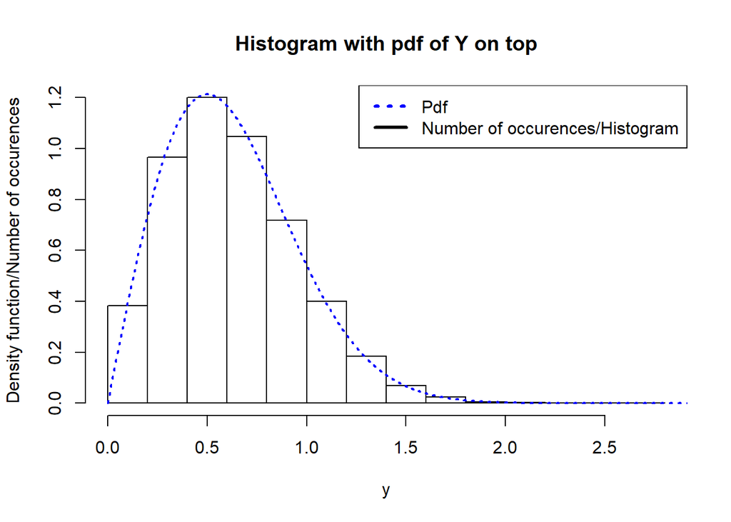

```r
num = 100000
lambda = 2

F_inverse <- function(u, lambda){
  f_inv = sqrt(-log(1-u)/lambda)
  return(f_inv)
}

calc_pdf <- function(y, lambda){
  pdfy = 2*y*lambda*exp(-2*y^2)
  return(pdfy)
}

u = runif(num, 0, 1)
y = F_inverse(u, lambda)
#Plotting Histogram
hist(y, freq=FALSE, main = "Histogram with pdf of Y on top", ylab = "Density function/Number of occurences")

#first way to calculate pdfy
x = seq(0.00001, 10, lambda/1000)
pdfy = calc_pdf(x, lambda)

lines(x, pdfy, lwd = 2, lty = 3, col = "blue")

#second way to calculate pdfy (just uncomment it and comment the above one if you want to see this)
#pdfy = calc_pdf(y, lamda)
#lines(x, pdfy, type = 'p', lwd = 2, lty = 3, col = "blue")

legend("topright", c("Pdf", "Number of occurences/Histogram"),
       lty = c(3, 1), lwd = 3, col = c("blue", "black"))
```

```r
#Mean and Variance by the R function in the data
mean = mean(y)
variance = var(y)

#Mean and Variance Calculation by the derived formulas in Question 3
mean_original <- function(lambda){
  m = (1/lambda)*sqrt(pi/2)
  return(m)
}

var_original <- function(lambda){
  m = (1/lambda)*(1 - (pi/4))
  return(m)
}

mean_formula = mean_original(2)
variance_formula = var_original(2)

cat("The sample mean for the 10000 realizations is", mean)
```

[output not shown]

```r
cat("The mean calculated from the formula is ", mean_formula)
```

```
## The mean calculated from the formula is  0.6266571
```

```r
cat("The sample variance for the 10000 realizations is ", variance)
```

[output not shown]

```r
cat("The variance calculated from the formula is ", variance_formula)
```

```
## The variance calculated from the formula is  0.1073009
```

```r
cat("It can be observed that both the mean and variance are very close to each other")
```

```
## It can be observed that both the mean and variance are very close to each other
```

## Question 6 - Maximum Likelihood

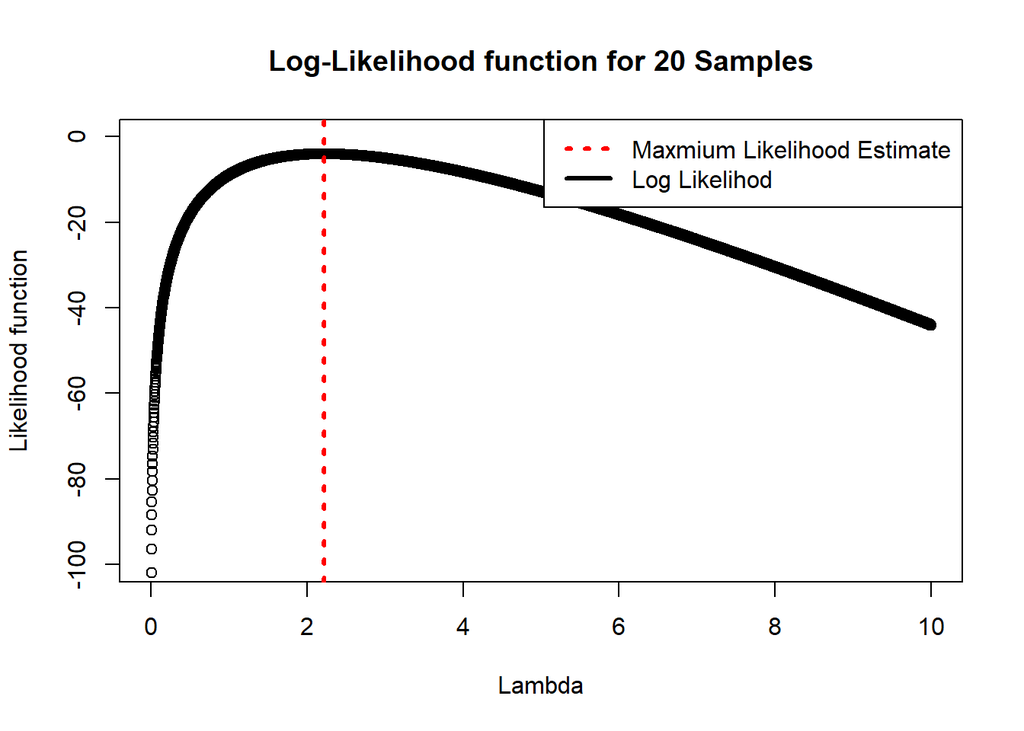

```r
log_lik <- function(y, lambda, n){
  log.lik = n * log(2*lambda) + sum(log(y)) - (lambda*sum(y^2))
  return (log.lik)
}
MLE <- function(y, num_samples){
  mle = num_samples/sum(y^2)
  return(mle)
}
num_samples = 20
l = seq(0.0001, 10, lambda/1000)
u = runif(num_samples, 0, 1)
y = F_inverse (u, lambda)

log.lik = log_lik(y, l, num_samples)

plot(l, log.lik, ylim = c(-100, 0), xlab = "Lambda", ylab = "Likelihood function", main = "Log-Likelihood function for 20 Samples", col = 'black')
m = MLE(y, num_samples)
abline(v = m, col='red', lwd = 3, lty = 3)

legend("topright", c("Maxmium Likelihood Estimate", "Log Likelihod"),
       lty = c(3, 1), lwd = 3, col = c("red", "black"))
```